# Aritmética de Ponto Flutuante

Os objetivos desta lição são

- Aprender sobre a representação de números naturais e inteiros na máquina;
- Aprender sobre Aritmética de Ponto Flutuante.

## Representação de Inteiros na máquina

Os computadores guardam inteiros de maneiras bastante específicas. Essas maneiras envolvem os bits de um computador, que matematicamente equivalem a números binários. Um bit pode estar ligado ou desligado, ou seja, 1 ou 0. Um inteiro de $n$ bits terá $n$ posições ordenadas que podem estar ligadas ou desligadas. Dessa maneira, é possível representar até $2^n$ inteiros com $n$ bits. A pergunta é quais $2^n$ inteiros?

Muitas vezes nos preocupamos apenas com os inteiros positivos, então uma escolha bastante simples seria os inteiros de $0$ à $2^n-1$. Esse tipo é dito "sem sinal" ou "Unsigned" em inglês. Em Julia, são os tipos `UIntN`, onde `N` é o número de bits (8, 16, 32, 64, 128).

Para inteiros positivos e negativos, uma maneira é guardar os númeos de $-2^{n-1}$ à $2^{n-1}-1$. Em binário, podemos escolher os $n-1$ bits da direita para fazer uma contagem de $0$ à $2^{n-1}-1$, e o bit mais à esquerda para indicar de começamos a contar de $-2^{n-1}$ ou de $0$.

### Exemplo com n = 3

| Bin | Dec |
| --- | --- |
| 000 | 0 |
| 001 | 1 |
| 010 | 2 |
| 011 | 3 |
| 100 | -4 |
| 101 | -3 |
| 110 | -2 |
| 111 | -1 |

Note que o problema de trabalhar com inteiros que caiam fora deste intervalo está nas operações básicas mesmo:

```
3 + 1  (em decimal)

         1     1
 011    011    011    011
 001    001    001    001
----   ----   ----   ----
   ?      0     00    100
```

Mas `100` nessa representação significa `-4`, ou seja, a soma "dá a volta".

### Exemplo com n = 64 (o padrão)

O inteiro `Int64` vai de $-2^{63}$ à $2^{63}-1$.

```julia
x = 2^63-1
```

```
9223372036854775807
```

```julia
x + 1
```

```
-9223372036854775808
```

```julia
-x
```

```
-9223372036854775807
```

```julia
-x - 2
```

```
9223372036854775807
```

```julia
-(x+1) # = x + 1??
```

```
-9223372036854775808
```

```julia
x * x
```

```
1
```

```julia
y = 2^62
```

```
4611686018427387904
```

```julia
y * y
```

```
0
```

```julia
x * y
```

```
-4611686018427387904
```

Embora os valores máximos dos inteiros de 64 bits pareçam bastante grandes, eles podem ser alcançados com relativa facilidade.

```julia
factorial(20)
```

```
2432902008176640000
```

```julia
factorial(20) * 21
```

```
-4249290049419214848
```

### BigInt

Apesar do limite dos inteiros, muitas vezes queremos utilizar valores inteiros absurdamente grandes. Para isso existem **implementações** de números inteiros grandes - BigInts, para encurtar - que permitem, a priori, qualquer número inteiro. É importante notar a diferença entre um BigInt e um inteiro nativo. O BigInt **sempre** vem de uma implementação, enquanto que o inteiro nativo "existe" no processador. Todas as contas com BigInt serão mais lentas que em inteiros nativos, então não podemos simplesmente usar BigInt para tudo.

```julia
log2(4 * 10^(18))
```

```
61.794705707972525
```

```julia
big"2"^300
```

```
2037035976334486086268445688409378161051468393665936250636140449354381299763336706183397376
```

```julia
factorial(big"30")
```

```
265252859812191058636308480000000
```

# Introdução à pontos flutuantes

Nem só de inteiros vive o homem. Vamos falar sobre números de ponto flutuante na máquina, que é como representamos números reais (spoiler: só um subconjunto dos racionais, como veremos a seguir).

Um número em ponto flutuante é da forma $$ \pm 0.\mbox{mantissa} \times \mbox{base}^\mbox{expoente}, $$ onde a mantissa é uma sequência de dígitos entre 0 e a base menos 1.

### Exemplos

$$ 234 = 0.234 \times 10^3 $$$$ -12.5 = -.125 \times 10^2 $$$$ 0.001 = 0.1 \times 10^{-2} $$$$ (101)_2 = (0.101)_2 \times 2^3. $$

Veja que a notação é muito parecida com a notação científica.

Números em ponto flutuante são armazenados numa quantidade finita de bits - normalmente, 64 bits. A base escolhida é a base 2, e tanto a mantissa quando o expoente são armazenados nesses 64 bits. O tipo em Julia que representa pontos flutuante de 64 bits é o Float64. Também existem o Float16 e o Float32, que usam 16 e 32 bits, respectivamente.

Lembre-se que os números 5 e 6 em binário são 101 e 110. Veja em Float16:

```julia
bitstring(Float16(5))
```

```
"0100010100000000"
```

```julia
bitstring(Float16(6))
```

```
"0100011000000000"
```

As primeiras casas indicam o expoente, e as últimas indicam a mantissa.

Existem vários detalhes da implementação de ponto flutuante que iremos deixar de lado. Vamos olhar apenas de uma maneira mais simples a parte teórica.

Note que teremos limitações para a mantissa e expoente. Em particular, na base 10, pensaremos que a mantissa tem uma limitação no número de dígitos depois da vírgula, e o expoente estará limitada entre valores $L$ e $U$ como $L \leq E \leq U$. Note que isso implica que existem valores máximos e mínimos.

Por exemplo, com 3 dígitos na mantissa e um expoente limitado por $-3 \leq E \leq 4$, o máximo será $$ X_{\max} = 0.999 \times 10^4 \approx 10^4, $$ o menor número positivo será $$ X_{\min} = 0.001 \times 10^{-3} = 10^{-6}. $$

O conjunto dos números de pontos flutuante não abrange todas as possibilidades de números que poderiam ser representados com a quantidade de bits dada. Por exemplo, $0\times 10^n$ ainda é zero, independente do $n$. Sendo assim, existem várias sequências de bits "livres", que podem ser usados para representar outras coisas. Em particular, nos pontos flutuantes é possível representar um valor infinito:

```julia
Inf
```

```
Inf
```

```julia
Inf > 1e300
```

```
true
```

```julia
1 / Inf
```

```
0.0
```

```julia
Inf + Inf
```

```
Inf
```

e também um valor que indica que a operação realizada contém alguma incoerência, o *NotANumber*, ou *NaN*.

```julia
NaN
```

```
NaN
```

```julia
0 / 0
```

```
NaN
```

```julia
Inf - Inf
```

```
NaN
```

**Cuidado:** O NaN é contagioso. Se ao programar você encontrar um NaN, você deve examinar seu código, descobrir o que está causando ele, e evitar esse problema.

```julia
NaN + 1
```

```
NaN
```

```julia
NaN - NaN
```

```
NaN
```

```julia
1 / NaN
```

```
NaN
```

**Representação gráfica dos floats**

Abaixo, veremos todos os números em ponto flutuante (ou o que dá pra ver).

Para cada ponto em azul, a abscissa corresponde à um ponto flutuante, e ordenada desse ponto é a distância entre um ponto e o ponto imediatamente antes dele.

```julia
using Plots
gr(size=(600,400))
default(fmt = :png)
```

```julia
x = Float16(0.0)
X = Float16[0.0]
D = Float16[0.0]
while x < Inf
    y = nextfloat(x)
    d = y - x
    x = y
    push!(X, x)
    push!(D, d)
end
println(log2.(unique(D)))
```

```
Float16[-Inf, -24.0, -23.0, -22.0, -21.0, -20.0, -19.0, -18.0, -17.0, -16.0, -15.0, -14.0, -13.0, -12.0, -11.0, -10.0, -9.0, -8.0, -7.0, -6.0, -5.0, -4.0, -3.0, -2.0, -1.0, 0.0, 1.0, 2.0, 3.0, 4.0, 5.0, Inf]
```

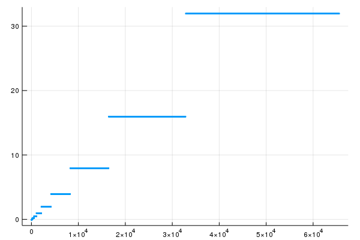

```julia
scatter(X, D, ms=1, m=(stroke(0)), leg=false)
```

Veja que as distância são as potências de 2.

A base tradicionalmente é 2 nos computadores, e os bits atribuídos a um número desses é separado em uma parte para a mantissa e outra para o expoente. Em particular, com 64 bits, usamos 53 dígitos para a mantissa e 11 para o expoente. Um dos bits da mantissa guarda o sinal do elemento.

Um aspecto essencial dos pontos flutuantes é que eles representam apenas uma quantidade finita de pontos, e como a quantidade dígitos depois da vírgula da mantissa também é finita, apenas os racionais podem ser representados.

No entanto, no computador usamos a base 2, e alguns números que não são dízimos na base 10 podem ser dízima na base 2. Por exemplo, 0.1.

Veja que $$S = 1 + \frac{1}{2^4} + \frac{1}{2^8} + \frac{1}{2^{12}} + \dots = \frac{1}{1 - 2^{-4}} = \frac{16}{15}.$$ Daí, $$\frac{1}{2^4}(S + \tfrac{1}{2}S) = \frac{1}{16}\times\frac{24}{15} = \frac{1}{10}.$$

Por outro lado, $(S)_2 = 1.0001000100010001\dots$, então $$\frac{1}{10} = \frac{1}{2^4}(1.000100010\dots + 0.100010001\dots = \frac{1}{2^4}(1.100110011\dots) = 0.000110011001100\dots$$

```julia
using Printf

@printf("%20.18f\n", 0.1)
```

```
0.100000000000000006
```

```julia
@printf("%20.18f\n", 0.5)
```

```
0.500000000000000000
```

Apesar de não parecer muito, essa pequena diferença levará a erros como o abaixo:

```julia
0.1 + 0.2 - 0.3
```

```
5.551115123125783e-17
```

## Aritmética de Ponto Flutuante

Além do armazenamento, também é importante definir a **aritmética de ponto flutuante**.

Dado dois números armazenados na mesma base, a operação de soma ou subtração entre os dois ocorre da seguinte forma:

```julia
#=
    Entrada: dois numeros x₁ = M₁×βᴱ¹ e x₂ = M₂×βᴱ².
1. Calcule o maior expoente E = max(E₁, E₂)
2. Escreva os dois números usando este expoente
    x₁ = (M₁ × βᴱ¹⁻ᴱ) × βᴱ
    x₂ = (M₂ × βᴱ²⁻ᴱ) × βᴱ
3. Some os dois
    x₃ = x₁ + x₂ = (M₁ × βᴱ¹⁻ᴱ + M₂ × βᴱ²⁻ᴱ) × βᴱ
4. Calcule a mantissa M₃ e expoente E₃ do número novo
    x₃ = M₃×βᴱ³
=#
```

Observe, no entanto, que como a mantissa e o expoente são guardados usando uma quantidade finita de bits, então podemos acabar perdendo informação.

Vamos fazer uma simulação dessa operação uma mantissa de 3 dígitos além da vírgula, e um expoente com limitantes $-5 \leq E \leq 4$, na base 10.

```julia
#=
    34.12  +  8.256

    3.412 × 10¹ + 8.256 × 10⁰
    3.412 × 10¹ + 0.8256 × 10¹
    (3.412 + 0.8256) × 10¹
    4.2376 × 10¹
    4.238 × 10¹ # Armazenado
    42.38
=#
```

Essa perda de dígitos é chamado de **erro de arredondamento**.

Em alguns casos, esse erro pode fazer com que um dos números somados seja tratado como zero.

```julia
#=
    2351 + 0.01234

    2.351 × 10³ + 1.234 × 10⁻²
    2.351 × 10³ + 0.00001234 × 10³
    (2.351 + 0.00001234) × 10³
    2.35101234 × 10³
    2.351 × 10³ # Armazenado
    2351
=#
```

No armazenamento IEEE754, é um pouco mais complicado chegar nos valores máximos e mínimos, mas eles ainda existem. Em particular, podemos usar o código abaixo para calcular qual o menor número positivo que é tratado como 0 quando somado à 1.

```julia
ϵ = 1.0
while 1.0 + ϵ > 1.0
    ϵ = ϵ/2
end
ϵ = 2ϵ
```

```
2.220446049250313e-16
```

```julia
eps(Float64)
```

```
2.220446049250313e-16
```

```julia
eps(Float16)
```

```
Float16(0.000977)
```

Esse número é chamado de **precisão da máquina**, e às vezes denotado por $\epsilon_{\mbox{machine}}$. Para todo número real $x$, existe um número $x'$ em ponto flutuante tal que $$ |x - x'| \leq \epsilon_{\mbox{machine}}|x|. $$

```julia
eps(0.3)
```

```
5.551115123125783e-17
```

```julia
0.1 + 0.2 - 0.3
```

```
5.551115123125783e-17
```

A multiplicação é mais simples. Os expoentes são somados, as mantissas multiplicadas, e os valores são arredondados e ajustados de modo a ficar na forma de ponto flutuante. Análogo para divisão.

Nos pontos flutuantes de 64 bits (`Float64` no Julia), o maior valor representável nessa base é por volta de $10^{308}$ e o menor positivo é $5\times10^{-324}$. Diferente do que acontece com inteiros, quando fazemos alguma coisa que ultrapassa o maior valor, nós temos o chamado **overflow**. Denotaremos o número como $\infty$ (infinito), ou `Inf` em Julia. Se algum cálculo resultar em um valor positivo que o menor valor positivo, obtemos um chamado **underflow**, e o valor é considerado 0.

```julia
x = 2.0
```

```
2.0
```

```julia
x = x^x
```

```
4.0
```

Denotamos por $\mbox{fl}(x)$ o número em ponto flutuante mais próximo do real $x$. Temos que para cada $x \in \mathbb{R}$, existe $\epsilon$ tal que $|\epsilon| \leq \epsilon_{\mbox{machine}}$ e $\mbox{fl}(x) = x(1+\epsilon)$.

Como não estamos trabalhando nos reais (às vezes escrevemos $\mathbb{F}$), então as operações básicas não estão mais definidas como antes. Por exemplo, $\mbox{fl}(1) = 1$ e $\mbox{fl}(10) = 10$, mas $1/10 \neq \mbox{fl}(1/10)$.

Sendo assim, redefinimos as operações de soma, subtração, divisão e multiplicação. Seja $\ast$ uma das operações $+, -, \times, \div$, e seja $\circledast$ a operação correspondente em ponto flutuante, dada por $$ x \circledast y = \mbox{fl}(x \ast y). $$

Se pudermos definir um computador com as operações acima, teremos o chamado **Axioma Fundamental da Aritmética de Ponto Flutuante**: Para todo $x, y \in \mathbb{F}$, existe $\epsilon$ com $|\epsilon| \leq \epsilon_{\mbox{machine}}$ tal que $$ x \circledast y = (x \ast y)(1 + \epsilon). $$

Note que a soma não é associativa.

```julia
(1.0 + 1e-16) + 1e-16 == 1.0 + (1e-16 + 1e-16)
```

```
false
```

```julia
((1.0 + 1e-16) + 1e-16)
```

```
1.0
```

```julia
(1.0 + (1e-16 + 1e-16))
```

```
1.0000000000000002
```

```julia
((1.0 + 1e-16) + 1e-16) - (1.0 + (1e-16 + 1e-16))
```

```
-2.220446049250313e-16
```

Por isso é bastante importante ter noção dos erros que estão acontecendo, para pensar na melhor maneira de se fazer certos cálculos.

$$ \frac{d}{dx}\bigg(\sqrt{x}\bigg)\bigg|_{x=a} = \lim_{h\to 0} \frac{\sqrt{a + h} - \sqrt{a}}{h} \approx \frac{\sqrt{a + h} - \sqrt{a}}{h}, $$

para algum $h$ pequeno e positivo.

```julia
h = 1e-14
a = 1.0
```

```
1.0
```

```julia
(sqrt(a + h) - sqrt(a)) / h
```

```
0.4884981308350689
```

```julia
(sqrt(a + h) - sqrt(a)) / h - 0.5
```

```
-0.011501869164931122
```

A aproximação ficou muito ruim. Mas veja que $$ \frac{\sqrt{a + h} - \sqrt{a}}{h} = \frac{a + h - a}{h(\sqrt{a + h} + \sqrt{a})} = \frac{1}{\sqrt{a + h} + \sqrt{a}}. $$

```julia
1 / (sqrt(a + h) + sqrt(a))
```

```
0.4999999999999988
```

```julia
1 / (sqrt(a + h) + sqrt(a)) - 0.5
```

```
-1.2212453270876722e-15
```

```julia
using Plots
gr(size=(600,400))
default(fmt=:png)
```

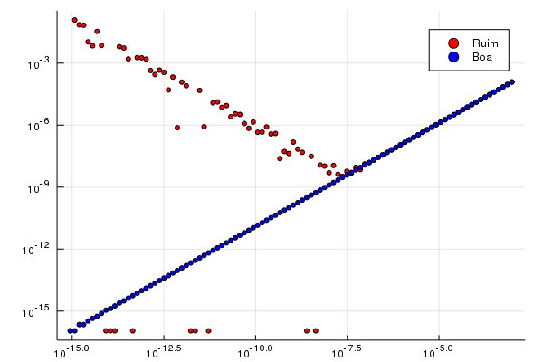

```julia
Ap1(h) = max(0.5 - (sqrt(1.0 + h) - sqrt(1.0)) / h, eps(Float64) / 2)
Ap2(h) = max(0.5 - 1 / (sqrt(1.0 + h) + sqrt(1.0)), eps(Float64) / 2)
valores_h = [2.0^p for p = range(-50, stop=-10, length=100)]

#plot(valores_h, fill(0.5, length(valores_h)), c=:black, l=:dash, lab="Exato")
plot(xaxis=:log, yaxis=:log)
scatter!(valores_h, Ap1.(valores_h), c=:red, lab="Ruim", ms=3)
scatter!(valores_h, Ap2.(valores_h), c=:blue, lab="Boa", ms=3)
```

Perceba que alguns ponto do "Ruim" na verdade tem um erro nulo. Isso acontece quando o ponto flutuante coincide com o valor real.

## Precisão Arbitrária

Da mesma maneira que às vezes queremos trabalhar com inteiros maiores que o máximo da máquina, às vezes também estamos interessados em pontos flutuantes com mais precisão que os da máquina. Em Julia, são chamados de `BigFloat`.

```julia
BigFloat(pi)
```

```
3.141592653589793238462643383279502884197169399375105820974944592307816406286198
```

```julia
eps(big"0.1")
```

```
1.079521069386805578173293982850049946389500045554535173127962933771073975395303e-78
```

```julia
sqrt(2.0)^2 - 2.0
```

```
4.440892098500626e-16
```

```julia
sqrt(big"2.0")^2 - big"2.0"
```

```
-1.727233711018888925077270372560079914223200072887256277004740694033718360632485e-77
```

```julia
nextfloat(big"0.0") # Menor positivo
```

```
8.50969131174083613912978790962048280567755996982969624908264897850135431080301e-1388255822130839284
```

Diferente dos `BigInt`s, os `BigFloat`s não crescem automaticamente. Devemos usar a função abaixo para escolher a precisão do mesmo.

```julia
setprecision(512)
```

```
512
```

```julia
nextfloat(big"0.0") # Menor positivo
```

```
8.50969131174083613912978790962048280567755996982969624908264897850135431080301037712781653863533176207041307677719465625590261564333325371457454023316728047e-1388255822130839284
```

```julia
BigFloat(pi)
```

```
3.14159265358979323846264338327950288419716939937510582097494459230781640628620899862803482534211706798214808651328230664709384460955058223172535940812848115
```

## Aproximações da derivada

Como aplicação de aritmética de ponto flutuante, vamos considerar o problema de aproximar derivadas. A definição da derivada é $$ \lim_{h \rightarrow 0} \frac{f(x+h) - f(x)}{h}, $$ então podemos aproveitar essa definição é escolher um $h$ pequeno e não nulo para aproximar essa derivada.

Vamos testar essa aproximação com $f(x) = e^x$, cuja derivada é $f'(x)$.

```julia
DF(x, h) = (exp(x+h) - exp(x))/h
```

```
DF (generic function with 1 method)
```

```julia
f(x) = exp(x)
```

```
f (generic function with 1 method)
```

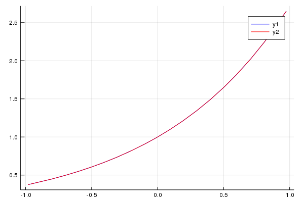

```julia
# Aproximação para $h = 1e-4$
h = 1e-4
plot(f, -1, 1, c=:blue)
plot!(x->DF(x, h), -1, 1, c=:red)
```

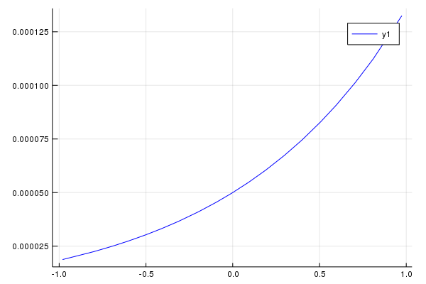

```julia
plot(x->DF(x, h) - f(x), -1, 1, c=:blue)
```

Essa aproximação parece bastante boa. Vamos ver num intervalo maior.

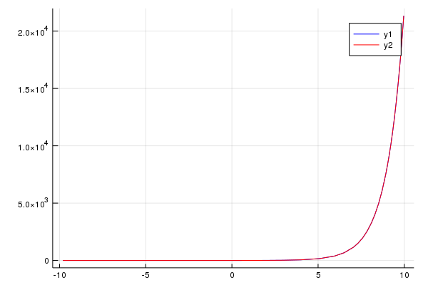

```julia
# Aproximação para $h = 1e-4$
h = 1e-4
plot(f, -10, 10, c=:blue)
plot!(x->DF(x, h), -10, 10, c=:red)
```

Vamos ver o erro dessa aproximação.

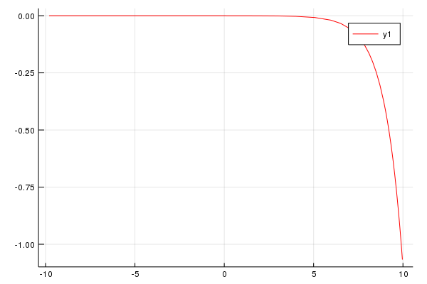

```julia
# Aproximação para $h = 1e-4$
h = 1e-4
plot(x->f(x) - DF(x, h), -10, 10, c=:red)
```

```julia
abs(f(1.0) - DF(1.0, 1e-4))/f(1.0)
```

```
5.000166739738369e-5
```

Razoavelmente esperado, o erro está na casa dos $5\times 10^{-5}$. Vamos diminuir o valor de $h$.

```julia
(f(1.0) - DF(1.0, 1e-5))/f(1.0)
```

```
-5.000032568337868e-6
```

Também esperado, o erro diminui. Vamos tentar um $h$ bem menor.

```julia
(f(1.0) - DF(1.0, 1e-15))/f(1.0)
```

```
-0.1435990324493588
```

Ora, o erro aumentou bastante. Como você deve suspeitar, isso acontece por causa dos erros de cancelamento. Vejamos um gráfico do erro em função de $h$.

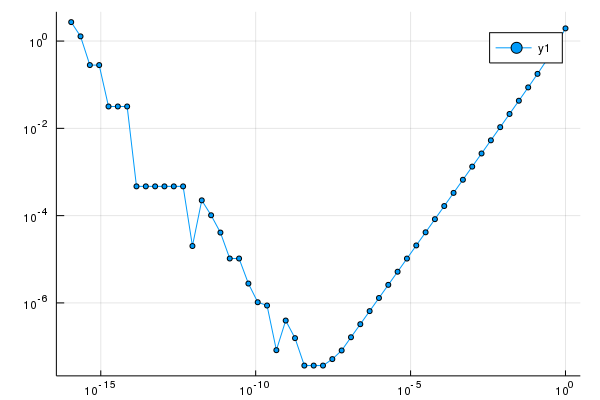

```julia
hs = []
Es = []
h = 1.0
x = 1.0
while h > 1e-16
    E = abs(f(x) - DF(x, h))
    push!(hs, h)
    push!(Es, E)
    h = h / 2
end
plot(hs, Es, m=3, xaxis=:log, yaxis=:log)
```

Pelo gráfico podemos ver que o erro diminui até por volta de $10^{-8}$, e depois aumenta, erraticamente. Vamos tentar descobrir teoricamente o motivo disso.

Vamos usar o Teorema de Taylor com resto para encontrar um limitante para a derivada aproximada. Veja que expandindo $f(x+h)$ em torno de $x$, temos $$ f(x + h) = f(x) + f'(x)h + \frac{h^2}{2}f''(\xi), $$ onde $\xi$ é um valor entre $x$ e $h$. Isso quer dizer que $$ f'(x) = \frac{f(x+h) - f(x)}{h} - \frac{h}{2}f''(\xi). $$

Isso nos dá um embasamento teórico de porque o erro diminui inicialmente, e porque é proporcional à $h/2$. No entanto, lembre-se que computacionalmente não conseguimos calcular $f(x)$ exatamente. Na prática estamos calculando um valor $\overline{f}(x)$ e $\overline{f}(x+h)$, e daí $$ D_h(x) = \frac{\overline{f}(x+h) - \overline{f}(x)}{h}. $$

Lembre-se da limitação do erro é dada por um valor $\epsilon$ com $|\epsilon| < \epsilon_M$ (da máquina), e portanto vamos usar diretamente $\epsilon_M$ como limitante: $$ |\overline{f}(x) - f(x)| \leq \epsilon_M |f(x)|, $$ e $$ |\overline{f}(x+h) - f(x+h)| \leq \epsilon_M |f(x+h)|. $$ Considerando nosso interesse num intervalo $(a,b)$ onde $x$ e $x+h$ residem, podemos limitar $|f(x)|$ por $L_1$ em todo esse intervalo, de modo que $$ |\overline{f}(x) - f(x)| \leq \epsilon_M L_1, $$ e $$ |\overline{f}(x+h) - f(x+h)| \leq \epsilon_M L_1. $$

[output not shown]

[output not shown]

Note que o limitante para o erro depende de $1/h$ além de depender de $h$. Isso quer dizer que a diminuição de $h$ faz o erro crescer bastante, apesar do termo linear dizer que o erro diminui. Felizmente, temos $1/h$ multiplicado por $\epsilon_M$, de modo que esse erro começa relativamente pequeno.

Os problemas comeração quando o erro da esquerda for maior que o da direita, começando de um valor grande de $h$ e tendendo à 0. Nessa direção, o valor da esquerda é crescente, e o da direta é decrescente. Então, podemos buscar onde eles ficam iguais, e a partir daquele instante saberemos quando o da esquerda fica maior que o da direita.

$$ \frac{2\epsilon_M L1}{h} = \frac{h}{2}L_2 \qquad \Rightarrow \qquad h = 2\sqrt{\frac{L_1}{L_2}}\sqrt{\epsilon_M}. $$

Os valores de $L_1$ e $L_2$ só podem ser obtidos em casos específicos, pois dependem da função $f$, de sua segunda derivada, do intervalo em questão, e de quão apertado é o limitante obtido. No entanto, é possível ver que existe uma dependência linear com o valor $\sqrt{\epsilon_M}$, que no caso de precisão dupla é $10^{-8}$. Não por acaso, o valor que vimos no gráfico.

Além disso, veja o valor que o limitante obtém quando substituímos esse valor de $h$: $$ 2\sqrt{\epsilon_M}\sqrt{L_1L_2}. $$ Esse valor também condiz com o valor encontrado no gráfico.

Agora, vamos fazer a mesma análise com a seguinte aproximação para a derivada, chamada de diferença centrada, $$ f'(x) = \frac{f(x+h) - f(x-h)}{2h} - \frac{h^2}{6}f''(\xi). $$

**Exercício:** Faça a mesma análise que fizemos anteriormente para encontrar um valor ótimo para $h$ que minimize o limitante do erro, e também o valor desse limitante no $h$ ótimo. Compare seus resultados com o do gráfico abaixo.

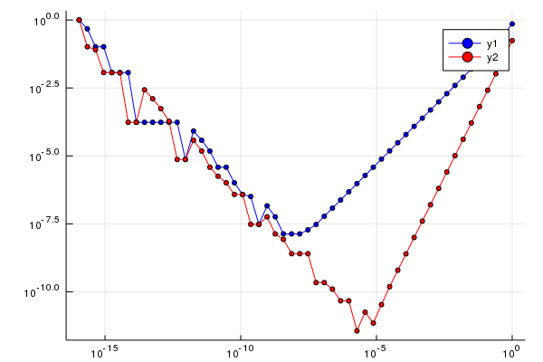

```julia
D_av(f, x, h) = (f(x + h) - f(x)) / h
D_ct(f, x, h) = (f(x + h) - f(x - h)) / 2h
hs = []
E_av = []
E_ct = []
E_ct2 = []
h = 1.0
x = 1.0
f(x) = exp(x)
fx = exp(x)
while h > 1e-16
    push!(hs, h)
    E = abs(fx - D_av(f, x, h))/abs(fx)
    push!(E_av, E)
    E = abs(fx - D_ct(f, x, h))/abs(fx)
    push!(E_ct, E)
    h = h /= 2
end
plot(hs, E_av, m=3, xaxis=:log, yaxis=:log, c=:blue)
plot!(hs, E_ct, m=3, xaxis=:log, yaxis=:log, c=:red)
```

A mesma análise pode ser feita para a segunda derivada, assim como outras. Além disso, existem várias maneiras de se aproximar as derivadas, utilizando mais avaliações da função $f$.

# Exercícios

Faça os exercícios do capítulo 1 do livro Cálculo Numérico de Ruggiero e Lopes.

1. Para cada sequência abaixo, calcule o maior termo que pode ser representado por um inteiro de 64 bits sem sinal.
   - $a_n = 2^n$;
   - $a_n = 3n + 5$;
   - $a_n = q a_{n-1}$ onde $q > 1$ e $a_0 = 1$;
   - $a_n = n!$ (use o computador):
   - $a_n = a_{n-1} + a_{n-2}$, com $a_0 = a_1 = 1$.
2. Sabendo que a primeira e segunda derivadas de $f$ em $x$ existem, calcule os seguintes limites. (Nota: Para real emoção, não use L'Hôpital).
   - $\displaystyle \lim _ {h \to 0} \dfrac{f(x-h) - f(x)}{h}$;
   - $\displaystyle \lim _ {h \to 0} \dfrac{f(x+h) - f(x-h)}{h}$;
   - $\displaystyle \lim _ {h \to 0} \dfrac{f(x+2h) - 2f(x+h) + f(x)}{h}$;
   - $\displaystyle \lim _ {h \to 0} \dfrac{f(x+h) - 2f(x) + f(x-h)}{h^2}$;
   - $\displaystyle \lim _ {h \to 0} \dfrac{f(x + \alpha h) - f(x - \alpha h)}{h}$, $\alpha \neq 0$.